# Homework #7

Viet Ba Mai

29 listopada 2016

# Description

The goal of this homework is to compare the performance of Naive Bayes classifier on a data with categorized variables of similar intervals (lengths) versus similar number of observations (size) for each subgroup. In both cases the variables will be divided into 3 ranges.

The first categorisation will be done with `cut()` while the latter with `cut2()` from `Hmisc` library.

The dataset used for this project is `Wine Quality` from UCI (http://archive.ics.uci.edu/ml/machine-learning-databases/wine-quality/winequality.names).

```r
library(caret)
library(Hmisc)
library(randomForest)

wines <- read.csv(file.path(getwd(), "wines.csv"), header=TRUE, sep=",", encoding="UTF-8")
table(wines$quality)
```

```
##
##   3   4   5   6   7   8
##  10  53 681 638 199  18
```

```r
wines$quality <- factor(ifelse(wines$quality > 5, "good", "bad"))
table(wines$quality)
```

```
##
##  bad good
##  744  855
```

```r
summary(wines)
```

```
##  fixed.acidity   volatile.acidity  citric.acid    residual.sugar
##  Min.   : 4.60   Min.   :0.1200   Min.   :0.000   Min.   : 0.900
##  1st Qu.: 7.10   1st Qu.:0.3900   1st Qu.:0.090   1st Qu.: 1.900
##  Median : 7.90   Median :0.5200   Median :0.260   Median : 2.200
##  Mean   : 8.32   Mean   :0.5278   Mean   :0.271   Mean   : 2.539
##  3rd Qu.: 9.20   3rd Qu.:0.6400   3rd Qu.:0.420   3rd Qu.: 2.600
##  Max.   :15.90   Max.   :1.5800   Max.   :1.000   Max.   :15.500
##    chlorides       free.sulfur.dioxide total.sulfur.dioxide
##  Min.   :0.01200   Min.   : 1.00       Min.   :  6.00
##  1st Qu.:0.07000   1st Qu.: 7.00       1st Qu.: 22.00
##  Median :0.07900   Median :14.00       Median : 38.00
##  Mean   :0.08747   Mean   :15.87       Mean   : 46.47
##  3rd Qu.:0.09000   3rd Qu.:21.00       3rd Qu.: 62.00
##  Max.   :0.61100   Max.   :72.00       Max.   :289.00
##     density             pH          sulphates         alcohol
##  Min.   :0.9901   Min.   :2.740   Min.   :0.3300   Min.   : 8.40
##  1st Qu.:0.9956   1st Qu.:3.210   1st Qu.:0.5500   1st Qu.: 9.50
##  Median :0.9968   Median :3.310   Median :0.6200   Median :10.20
##  Mean   :0.9967   Mean   :3.311   Mean   :0.6581   Mean   :10.42
##  3rd Qu.:0.9978   3rd Qu.:3.400   3rd Qu.:0.7300   3rd Qu.:11.10
##  Max.   :1.0037   Max.   :4.010   Max.   :2.0000   Max.   :14.90
##  quality
##  bad :744
##  good:855
##
##
##
##
```

# Creating subranges

Firstly we create copies of the original dataset. In the next steps we will categorise features into 3 sub-ranges.

```r
wines_eq_length <- wines
wines_eq_size <- wines
```

## Similar intervals

Dividing into sub-ranges of similar length of the range using `cut()` function.

```r
for (i in 1:11) {
  wines_eq_length[,i] <- cut(wines[,i], 3)
}
summary(wines_eq_length)
```

```
##      fixed.acidity      volatile.acidity         citric.acid
##  (4.59,8.37]:969   (0.119,0.607]:1098    (-0.001,0.333]:1009
##  (8.37,12.1]:572   (0.607,1.09] : 493    (0.333,0.667] : 555
##  (12.1,15.9]: 58   (1.09,1.58]  :   8    (0.667,1]     :  35
##       residual.sugar          chlorides      free.sulfur.dioxide
##  (0.885,5.77]:1540   (0.0114,0.212]:1560   (0.929,24.7]:1289
##  (5.77,10.6] :  48   (0.212,0.411] :  28   (24.7,48.3] : 292
##  (10.6,15.5] :  11   (0.411,0.612] :  11   (48.3,72.1] :  18
##  total.sulfur.dioxide          density               pH
##  (5.72,100]:1472      (0.99,0.995] : 171   (2.74,3.16]: 267
##  (100,195] : 125      (0.995,0.999]:1270   (3.16,3.59]:1269
##  (195,289] :   2      (0.999,1]    : 158   (3.59,4.01]:  63
##          sulphates           alcohol    quality
##  (0.328,0.887]:1482   (8.39,10.6]:985   bad :744
##  (0.887,1.44] : 109   (10.6,12.7]:559   good:855
##  (1.44,2]     :   8   (12.7,14.9]: 55
```

## Similar sizes

Dividing into sub-ranges of similar size (number of observations) using `cut()2` function.

```r
for (i in 1:11) {
  wines_eq_size[,i] <- cut2(wines[,i], g=3)
}
summary(wines_eq_size)
```

```
##     fixed.acidity      volatile.acidity      citric.acid
##  [4.6, 7.5):574   [0.120,0.440):555     [0.00,0.16):538
##  [7.5, 8.9):525   [0.440,0.605):540     [0.16,0.37):528
##  [8.9,15.9]:500   [0.605,1.580]:504     [0.37,1.00]:533
##       residual.sugar         chlorides   free.sulfur.dioxide
##  [0.90, 2.05):620    [0.012,0.075):571   [ 1,11):605
##  [2.05, 2.50):460    [0.075,0.086):498   [11,19):486
##  [2.50,15.50]:519    [0.086,0.611]:530   [19,72]:508
##  total.sulfur.dioxide          density              pH
##  [ 6, 27):534         [0.990,0.996):534   [2.74,3.26):550
##  [27, 53):545         [0.996,0.997):545   [3.26,3.38):529
##  [53,289]:520         [0.997,1.004]:520   [3.38,4.01]:520
##        sulphates          alcohol    quality
##  [0.33,0.58):535   [ 8.4, 9.8):552   bad :744
##  [0.58,0.69):542   [ 9.8,10.9):531   good:855
##  [0.69,2.00]:522   [10.9,14.9]:516
```

# Naive Bayes

Having two types of data prepared we will create Naive Bayes classifiers for each to check which will give a better performance.

## Similar intervals

```r
bayes_length <- train(quality ~ ., data=wines_eq_length, trControl=trainControl(method="boot", number=10), method="nb")
pred <- predict(bayes_length, wines_eq_length)
confusionMatrix(pred, wines_eq_length$quality)
```

```
## Confusion Matrix and Statistics
##
##           Reference
## Prediction bad good
##       bad  262   69
##       good 482  786
##
##                Accuracy : 0.6554
##                  95% CI : (0.6315, 0.6787)
##     No Information Rate : 0.5347
##     P-Value [Acc > NIR] : < 2.2e-16
##
##                   Kappa : 0.2816
##  Mcnemar's Test P-Value : < 2.2e-16
##
##             Sensitivity : 0.3522
##             Specificity : 0.9193
##          Pos Pred Value : 0.7915
##          Neg Pred Value : 0.6199
##              Prevalence : 0.4653
##          Detection Rate : 0.1639
##    Detection Prevalence : 0.2070
##       Balanced Accuracy : 0.6357
##
##        'Positive' Class : bad
##
```

## Similar sizes

```r
bayes_sizes <- train(quality ~ ., data=wines_eq_size, trControl=trainControl(method="boot", number=10), method="nb")
pred <- predict(bayes_sizes, wines_eq_size)
confusionMatrix(pred, wines_eq_size$quality)
```

```
## Confusion Matrix and Statistics
##
##           Reference
## Prediction bad good
##       bad  530  249
##       good 214  606
##
##                Accuracy : 0.7104
##                  95% CI : (0.6875, 0.7326)
##     No Information Rate : 0.5347
##     P-Value [Acc > NIR] : <2e-16
##
##                   Kappa : 0.4199
##  Mcnemar's Test P-Value : 0.1141
##
##             Sensitivity : 0.7124
##             Specificity : 0.7088
##          Pos Pred Value : 0.6804
##          Neg Pred Value : 0.7390
##              Prevalence : 0.4653
##          Detection Rate : 0.3315
##    Detection Prevalence : 0.4872
##       Balanced Accuracy : 0.7106
##
##        'Positive' Class : bad
##
```

# Importance

Now we will experiment with feature importance. Using Random Forest we find the top 3 most important predictors and then train with Naive Bayes using only them.

## Similar intervals

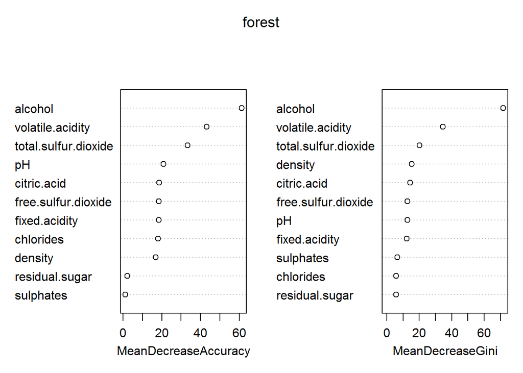

```r
set.seed(1313)
indxTrain <- createDataPartition(y = wines_eq_length$quality, p = 0.75)
train <- wines_eq_length[indxTrain$Resample1,]

forest <- randomForest(quality ~ ., data = train, importance = TRUE, na.action = na.omit)
varImpPlot(forest)
```

```r
importance(forest)
```

```
##                             bad      good MeanDecreaseAccuracy
## fixed.acidity        11.7080802  6.080674            18.347620
## volatile.acidity     42.9602923 19.028178            43.111414
## citric.acid           8.1153613 10.770603            18.654228
## residual.sugar       -6.5520772  8.231308             2.053497
## chlorides            15.2479053 10.448083            17.988782
## free.sulfur.dioxide  16.9377990  8.755428            18.436460
## total.sulfur.dioxide 19.1629974 31.002307            33.245981
## density               9.5044362  9.597962            16.913636
## pH                   -0.9565611 22.044318            20.867564
## sulphates             3.4955373 -2.387736             1.132090
## alcohol              52.1817105 45.371898            61.325202
##                      MeanDecreaseGini
## fixed.acidity               12.337450
## volatile.acidity            34.649591
## citric.acid                 14.398076
## residual.sugar               5.681391
## chlorides                    5.711670
## free.sulfur.dioxide         12.816877
## total.sulfur.dioxide        20.163861
## density                     15.233673
## pH                          12.618890
## sulphates                    6.438843
## alcohol                     71.752542
```

```r
sortedImportance = order(-forest$importance[,3])
tops = rownames(forest$importance)[sortedImportance][1:3][1:3]
tops
```

```
## [1] "alcohol"              "volatile.acidity"     "total.sulfur.dioxide"
```

```r
tops <- append(tops, "quality")
wines_eq_length <- wines_eq_length[tops]

bayes_length <- train(quality ~ ., data=wines_eq_length, trControl=trainControl(method="boot", number=10), method="nb")
pred <- predict(bayes_length, wines_eq_length)
confusionMatrix(pred, wines_eq_length$quality)
```

```
## Confusion Matrix and Statistics
##
##           Reference
## Prediction bad good
##       bad  340   96
##       good 404  759
##
##                Accuracy : 0.6873
##                  95% CI : (0.6639, 0.71)
##     No Information Rate : 0.5347
##     P-Value [Acc > NIR] : < 2.2e-16
##
##                   Kappa : 0.3542
##  Mcnemar's Test P-Value : < 2.2e-16
##
##             Sensitivity : 0.4570
##             Specificity : 0.8877
##          Pos Pred Value : 0.7798
##          Neg Pred Value : 0.6526
##              Prevalence : 0.4653
##          Detection Rate : 0.2126
##    Detection Prevalence : 0.2727
##       Balanced Accuracy : 0.6724
##
##        'Positive' Class : bad
##
```

## Similar sizes

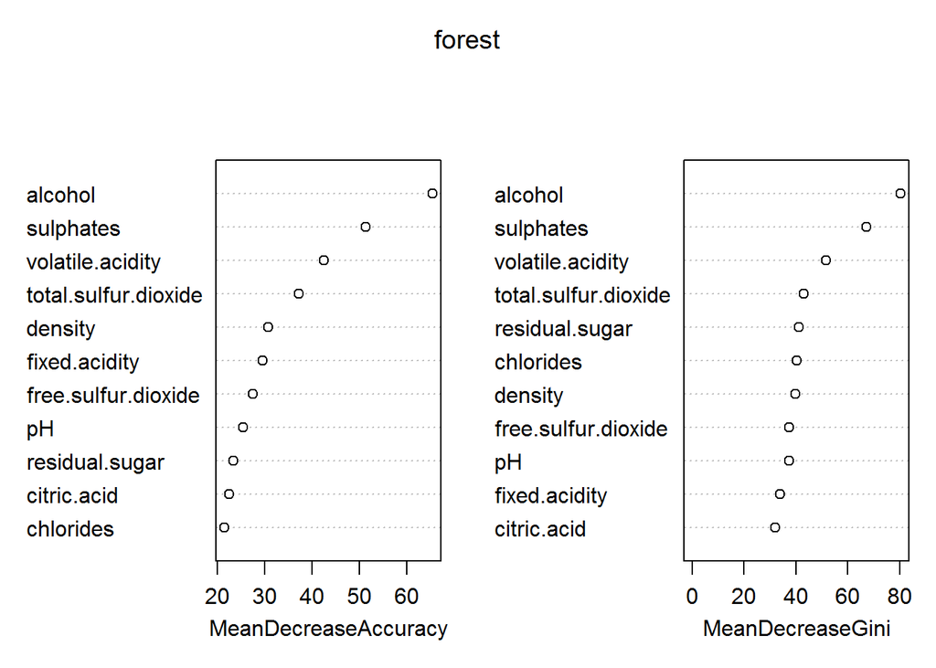

```r
set.seed(1313)
indxTrain <- createDataPartition(y = wines_eq_size$quality, p = 0.75)
train <- wines_eq_size[indxTrain$Resample1,]

forest <- randomForest(quality ~ ., data = train, importance = TRUE, na.action = na.omit)
varImpPlot(forest)
```

```r
importance(forest)
```

```
##                           bad     good MeanDecreaseAccuracy
## fixed.acidity        17.34624 20.53573             29.46961
## volatile.acidity     25.58714 33.37133             42.50856
## citric.acid          11.29041 16.23577             22.39491
## residual.sugar       12.81059 18.50590             23.28294
## chlorides            13.61382 16.53487             21.43976
## free.sulfur.dioxide  14.76753 22.99837             27.49491
## total.sulfur.dioxide 22.35399 28.91298             37.15436
## density              12.86711 26.51845             30.71098
## pH                   14.30721 20.18232             25.48000
## sulphates            37.50312 38.45618             51.31918
## alcohol              40.15914 54.95318             65.52935
##                      MeanDecreaseGini
## fixed.acidity                33.76291
## volatile.acidity             51.64920
## citric.acid                  32.05961
## residual.sugar               41.21319
## chlorides                    40.30505
## free.sulfur.dioxide          37.47850
## total.sulfur.dioxide         43.11895
## density                      39.83591
## pH                           37.37155
## sulphates                    67.12347
## alcohol                      80.43621
```

```r
sortedImportance = order(-forest$importance[,3])
tops = rownames(forest$importance)[sortedImportance][1:3][1:3]
tops
```

```
## [1] "alcohol"          "sulphates"        "volatile.acidity"
```

```r
tops <- append(tops, "quality")
wines_eq_size <- wines_eq_size[tops]

bayes_sizes <- train(quality~., data=wines_eq_size, trControl=trainControl(method="boot", number=10), method="nb")
pred <- predict(bayes_sizes, wines_eq_size)
confusionMatrix(pred, wines_eq_size$quality)
```

```
## Confusion Matrix and Statistics
##
##           Reference
## Prediction bad good
##       bad  569  297
##       good 175  558
##
##                Accuracy : 0.7048
##                  95% CI : (0.6818, 0.7271)
##     No Information Rate : 0.5347
##     P-Value [Acc > NIR] : < 2.2e-16
##
##                   Kappa : 0.413
##  Mcnemar's Test P-Value : 2.555e-08
##
##             Sensitivity : 0.7648
##             Specificity : 0.6526
##          Pos Pred Value : 0.6570
##          Neg Pred Value : 0.7613
##              Prevalence : 0.4653
##          Detection Rate : 0.3558
##    Detection Prevalence : 0.5416
##       Balanced Accuracy : 0.7087
##
##        'Positive' Class : bad
##
```

# Conclusions

The best result with the accuracy above `70%` was obtained when we divided features into categories of similar size. Classification only on the top 3 variables by importance yield less than `1%` lower results for the similar size categories, but in case of similar intervals division the result using only 3 features was `3%` higher (~`68%`).

We can conclude that in general it is a better idea to have the same amount of observations in each range rather than the same length of ranges.